# CAE_Z_Posterior_Boostrapping_Images_datasets_v0.1

```python
# http://proceedings.mlr.press/v101/huang19a/huang19a.pdf
# https://www.researchgate.net/publication/220875351_Generative_Models_for_Labeling_Multi-object_Configurations_in_Images
# https://www.tensorflow.org/datasets/catalog/open_images_v4
# Auto-Encoding Progressive Generative Adversarial Networks For 3D Multi Object Scenes
```

```python
# TODO
# for data set kitt (as AD case study) - for the built model
# 1. report model loss for validation dataset - Done
# 2. visualize reconstructed images - Done
# 3. Grid search (K, cov type) for gaussian mixture log p comparison (or baysian parameter optimization) - SKIP
# reason: nead to focus on core idea - GM is good other than G in Autonomous driving on a simplified case
# 4. read about inf Gaussian mixture  https://www.seas.harvard.edu/courses/cs281/papers/rasmussen-1999a.pdf
```

datasets to experiment

1. celeb_a : can't download
2. coil100 :
3. dsprites
4. flic
5. s3o4d
6. scene_parse150

```python
%config Completer.use_jedi = False
from ipywidgets import IntProgress
import matplotlib.pyplot as plt
from tensorflow.keras import layers, losses
import matplotlib.pyplot as plt
import numpy as np
import tensorflow as tf
import logging
import tensorflow_datasets as tfds
import pandas as pd
from tqdm import tqdm_notebook as tqdm
from sklearn.mixture import GaussianMixture
import os

seed = 1
np.random.seed(1)
tf.random.set_seed(1)
```

```python
batch_size = 32
epochs = 10
dataset_name = 'mnist'
```

```python
if dataset_name == 'bdd100k':
    train_ds = tf.keras.preprocessing\
        .image_dataset_from_directory(directory='../data/bdd100k/images/10k/train1/',batch_size=batch_size)# train
    test_ds = tf.keras.preprocessing\
        .image_dataset_from_directory(directory='../data/bdd100k/images/10k/test1/',batch_size=batch_size) # test
    validation_ds = tf.keras.preprocessing\
        .image_dataset_from_directory(directory='../data/bdd100k/images/10k/val1/',batch_size=batch_size) # validation
elif dataset_name in ['flic','fashion_mnist','mnist']:
    train_ds,test_ds = tfds.load(name=dataset_name,split=['train', 'test']\
                                               ,as_supervised=False,download=True)
    validation_ds = test_ds
elif dataset_name in ['wider_face']:
    train_ds,test_ds,validation_ds = tfds.load(name=dataset_name,split=['train', 'test','validation']\
                                               ,as_supervised=False,download=True)
else:
    raise ValueError(f'Unhandled dataset {dataset_name}')
```

```python
if dataset_name == 'bdd100k':
    dims = [x[0].get_shape().as_list() for x in train_ds]
    dims_df= pd.DataFrame.from_records(data=dims,columns=['batch','height','width','depth'])
else:
    dims = [x['image'].get_shape().as_list() for x in train_ds]
    dims_df= pd.DataFrame.from_records(data=dims,columns=['height','width','depth'])
dims_df.describe()
```

|  | height | width | depth |
| --- | --- | --- | --- |
| count | 60000.0 | 60000.0 | 60000.0 |
| mean | 28.0 | 28.0 | 1.0 |
| std | 0.0 | 0.0 | 0.0 |
| min | 28.0 | 28.0 | 1.0 |
| 25% | 28.0 | 28.0 | 1.0 |
| 50% | 28.0 | 28.0 | 1.0 |
| 75% | 28.0 | 28.0 | 1.0 |
| max | 28.0 | 28.0 | 1.0 |

```python
m = 2
height = int(min(dims_df['height'])/m)*m
width = int(min(dims_df['width'])/m)*m
# height = 2**(int(np.log2(min(dims_df['height']))))
# width = 2**(int(np.log2(min(dims_df['width']))))
depth = min(dims_df['depth'])
height,width = min(height,width),min(height,width)
height,width,depth
```

```
(28, 28, 1)
```

```python
for t in train_ds.take(3):
    print(t.keys())
```

```
dict_keys(['image', 'label'])
dict_keys(['image', 'label'])
dict_keys(['image', 'label'])
```

```python
if dataset_name == 'bdd100k':
    train_ds = train_ds.map(lambda x0,x1: x0/255.)
    test_ds = test_ds.map(lambda x0,x1: x0/255.)
    validation_ds = validation_ds.map(lambda x0,x1: x0/255.)
else:

    train_ds = train_ds.map(lambda x: tf.image.resize(images=tf.cast(x['image'],dtype=tf.float32)/255.,\
                                                      size=[height,width]))
    train_ds = train_ds.batch(batch_size,drop_remainder=True)
    ###
    test_ds = test_ds.map(lambda x: tf.image.resize(tf.cast(x['image'],dtype=tf.float32)/255.,\
                                                    size=[height,width]))
    test_ds = test_ds.batch(batch_size,drop_remainder=True)
    ###
    validation_ds = validation_ds.map(lambda x: tf.image.resize(tf.cast(x['image'],dtype=tf.float32)/255.\
                                                                ,size=[height,width]))
    validation_ds = validation_ds.batch(batch_size,drop_remainder=True)

###
train_ds_double_zipped = tf.data.Dataset.zip(datasets=(train_ds,train_ds))
test_ds_double_zipped = tf.data.Dataset.zip(datasets=(test_ds,test_ds))
validation_ds_double_zipped = tf.data.Dataset.zip(datasets=(validation_ds,validation_ds))
```

```python
latent_dim = 128
class CAE(tf.keras.Model):
    """Convolutional variational autoencoder."""

    def __init__(self, latent_dim):
        super(CAE, self).__init__()
        self.latent_dim = latent_dim
        self.logger = logging.getLogger('CAE')
        self.encoder = tf.keras.Sequential(name='encoder',layers=\
            [
                tf.keras.layers.InputLayer(input_shape=(height, width, depth)),
                tf.keras.layers.Conv2D(
                    filters=32, kernel_size=3, strides=(2, 2), activation='relu'),
                tf.keras.layers.Conv2D(
                    filters=64, kernel_size=3, strides=(2, 2), activation='relu'),
                tf.keras.layers.Flatten(),
                # No activation
                tf.keras.layers.Dense(latent_dim),
            ]
        )

        self.decoder = tf.keras.Sequential(name='decoder',layers=\
            [
                tf.keras.layers.InputLayer(input_shape=(latent_dim,)),
                tf.keras.layers.Dense(units=int(height/4) * int(width/4) * 32, activation=tf.nn.relu),
                tf.keras.layers.Reshape(target_shape=(int(height/4), int(width/4), 32)),
                tf.keras.layers.Conv2DTranspose(
                    filters=64, kernel_size=3, strides=2, padding='same',
                    activation='relu'),
                tf.keras.layers.Conv2DTranspose(
                    filters=32, kernel_size=3, strides=2, padding='same',
                    activation='relu'),
                # No activation
                tf.keras.layers.Conv2DTranspose(
                    filters=depth, kernel_size=3, strides=1, padding='same'),
            ]
        )

        self.encoder.summary()
        self.decoder.summary()


    def call(self, x):
        encoded = self.encoder(x)
        decoded = self.decoder(encoded)
        return decoded


cae = CAE(latent_dim)
cae.compile(optimizer='adam', loss=losses.MeanSquaredError())
```

```
Model: "encoder"
_________________________________________________________________
Layer (type)                 Output Shape              Param #
=================================================================
conv2d (Conv2D)              (None, 13, 13, 32)        320
_________________________________________________________________
conv2d_1 (Conv2D)            (None, 6, 6, 64)          18496
_________________________________________________________________
flatten (Flatten)            (None, 2304)              0
_________________________________________________________________
dense (Dense)                (None, 128)               295040
=================================================================
Total params: 313,856
Trainable params: 313,856
Non-trainable params: 0
_________________________________________________________________
Model: "decoder"
_________________________________________________________________
Layer (type)                 Output Shape              Param #
=================================================================
dense_1 (Dense)              (None, 1568)              202272
_________________________________________________________________
reshape (Reshape)            (None, 7, 7, 32)          0
_________________________________________________________________
conv2d_transpose (Conv2DTran (None, 14, 14, 64)        18496
_________________________________________________________________
conv2d_transpose_1 (Conv2DTr (None, 28, 28, 32)        18464
_________________________________________________________________
conv2d_transpose_2 (Conv2DTr (None, 28, 28, 1)         289
=================================================================
Total params: 239,521
Trainable params: 239,521
Non-trainable params: 0
_________________________________________________________________
```

```python
model_file_path = f'./models/cae_dataset_{dataset_name}_z_dim_{latent_dim}_data_dim_{height}x{width}x{depth}'
print(f'model path = {model_file_path}')
```

```
model path = ./models/cae_dataset_mnist_z_dim_128_data_dim_28x28x1
```

```python
if os.path.exists(model_file_path):
    print('loading saved model')
    cae = tf.keras.models.load_model(filepath=model_file_path)
else:
    print('building model')
    # use checkpoints to save model fitting progress
    # https://www.tensorflow.org/api_docs/python/tf/keras/callbacks/ModelCheckpoint
    checkpoint_filepath = './checkpoint'
    model_checkpoint_callback = tf.keras.callbacks.ModelCheckpoint(
        filepath=checkpoint_filepath,
        save_weights_only=True,
        monitor='val_loss',
        mode='max',
        save_best_only=True)
    # Model weights are saved at the end of every epoch, if it's the best seen
    # so far.
    cae.fit(x=train_ds_double_zipped,validation_data=test_ds_double_zipped,epochs=epochs,\
            callbacks=[model_checkpoint_callback],use_multiprocessing=True)
    # The model weights (that are considered the best) are loaded into the model.
    cae.load_weights(checkpoint_filepath)
    print('saving model')
    cae.save(filepath=model_file_path)
```

```
building model
saving model
INFO:tensorflow:Assets written to: ./models/cae_dataset_mnist_z_dim_128_data_dim_28x28x1/assets
```

```
INFO:tensorflow:Assets written to: ./models/cae_dataset_mnist_z_dim_128_data_dim_28x28x1/assets
```

```python
# create valdation dataset tensor
for e in validation_ds.take(1):
    initial_state = tf.zeros(dtype=tf.float32,shape=e.shape)
validation_ds_tensor = validation_ds.\
        reduce(initial_state=initial_state,reduce_func=lambda x,y: tf.concat(values=[x,y],axis=0))
validation_ds_tensor = validation_ds_tensor[batch_size:] # drop dummy initial state
```

```python
# calculate loss, can be compare over different dataset due to data scaling from 0 to 1
y_predicted = cae.predict(validation_ds)
cae_loss = cae.loss(y_pred=y_predicted,y_true=validation_ds_tensor).numpy()
print(f'CAE loss for dataset {dataset_name} = {np.round(cae_loss,4)}')
```

```
CAE loss for dataset mnist = 0.002300000051036477
```

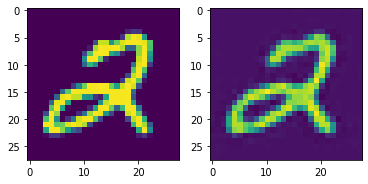

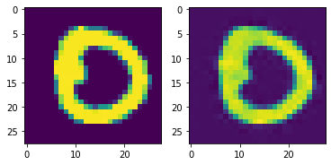

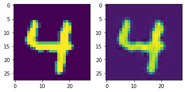

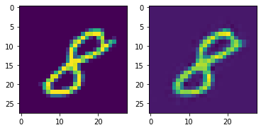

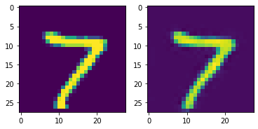

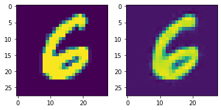

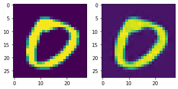

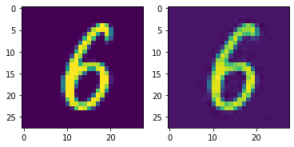

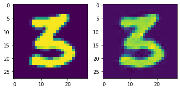

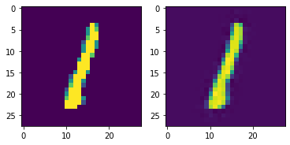

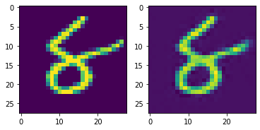

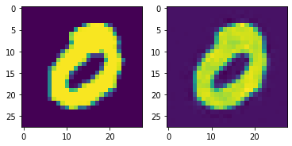

[52 more figures not shown]

```python
# plot decoded images

for batch in validation_ds.take(2):
        z = cae.encoder(batch).numpy()
        decoded_imgs = cae.decoder(z).numpy()

        for i in range(batch.shape[0]):
            fig, (ax1, ax2) = plt.subplots(1, 2)
            ax1.imshow(batch[i])
            ax2.imshow(decoded_imgs[i])
```

```python
# getting z tensor
z_tensor = None

inf_or_unknown_cardinality = ((test_ds.cardinality()==tf.data.INFINITE_CARDINALITY)\
    or (test_ds.cardinality() == tf.data.UNKNOWN_CARDINALITY)).numpy()
batches = test_ds.cardinality().numpy() if not inf_or_unknown_cardinality else 500

with tqdm(total=batches) as pbar:
    for batch in test_ds.take(batches):
        z = cae.encoder(batch).numpy()
        if z_tensor is None:
            z_tensor = tf.convert_to_tensor(z)
        else:
            z_tensor = tf.concat([z_tensor,tf.convert_to_tensor(z)],axis=0)
        pbar.update(1)
        #print(f'z shape {z.shape}')
#         decoded_imgs = cae.decoder(z).numpy()
#         #print(f'decoded images shape {decoded_imgs[0].shape}')
#         plt.imshow(batch[0])
#         plt.show()
#         plt.imshow(decoded_imgs[0])
#         plt.show()
z_tensor.shape
```

```
TensorShape([9984, 128])
```

```python
z_np= z_tensor.numpy()
n_z = z_np.shape[0]
n_z_train = int(0.8*n_z)
z_train = z_np[:n_z_train]
z_test = z_np[n_z_train:]
```

```python
random_state = 1
reg_covar = 0.1
cov_type = 'diag'

print(f"""For Dateset "{dataset_name}" Calculating relative difference of log likelihood  """)
print(f'Latent_dim = {latent_dim}, Gaussiam Mixture covariance type = {cov_type} and reg_covar = {reg_covar}   ')
print('############################  ')


g_fit = GaussianMixture(n_components=1,covariance_type=cov_type,random_state=1,reg_covar=reg_covar).fit(z_train)
logp_g = g_fit.score(X=z_test)
for k in [10,20,50,70,80,100,200]:
    try:
        gm_fit = GaussianMixture(n_components=k,covariance_type=cov_type,random_state=random_state,\
                                 reg_covar=reg_covar).fit(z_train)
        logp_gm = gm_fit.score(X=z_test)

        rel_diff_logps = (logp_gm- logp_g) / np.abs(logp_g)
        print(f'logp Gaussin Mixture with k = {k} = {logp_gm}  ')
        print(f'logp Gaussian Diagonal = {logp_g}  ')
        print(f'At k = {k} , rel_diff for logps = {rel_diff_logps}  ')
        print('##############  ')
    except Exception as e:
        print(f'Catched expection {e}  ')
```

```
For Dateset "mnist" Calculating relative difference of log likelihood
Latent_dim = 128, Gaussiam Mixture covariance type = diag and reg_covar = 0.1
############################
logp Gaussin Mixture with k = 10 = -50.921051989313966
logp Gaussian Diagonal = -63.584173438978944
At k = 10 , rel_diff for logps = 0.1991552420165946
##############
logp Gaussin Mixture with k = 20 = -45.807366359592805
logp Gaussian Diagonal = -63.584173438978944
At k = 20 , rel_diff for logps = 0.2795791172224068
##############
logp Gaussin Mixture with k = 50 = -39.238287129898154
logp Gaussian Diagonal = -63.584173438978944
At k = 50 , rel_diff for logps = 0.3828922354781458
##############
logp Gaussin Mixture with k = 70 = -36.8730307174611
logp Gaussian Diagonal = -63.584173438978944
At k = 70 , rel_diff for logps = 0.42009105846366385
##############
logp Gaussin Mixture with k = 80 = -36.1237147227589
logp Gaussian Diagonal = -63.584173438978944
At k = 80 , rel_diff for logps = 0.43187568904349377
##############
logp Gaussin Mixture with k = 100 = -34.92196790465145
logp Gaussian Diagonal = -63.584173438978944
At k = 100 , rel_diff for logps = 0.45077578246470884
##############
logp Gaussin Mixture with k = 200 = -31.015360558771256
logp Gaussian Diagonal = -63.584173438978944
At k = 200 , rel_diff for logps = 0.5122157153063196
##############
```

```python
random_state = 1
reg_covar = 0.1
cov_type = 'full'

print(f"""For Dateset "{dataset_name}" Calculating relative difference of log likelihood  """)
print(f'Latent_dim = {latent_dim}, Gaussiam Mixture covariance type = {cov_type} and reg_covar = {reg_covar}   ')
print('############################  ')


g_fit = GaussianMixture(n_components=1,covariance_type=cov_type,random_state=1,reg_covar=reg_covar).fit(z_train)
logp_g = g_fit.score(X=z_test)
for k in [10,20,50,70,80,100,200]:
    try:
        gm_fit = GaussianMixture(n_components=k,covariance_type=cov_type,random_state=random_state,\
                                 reg_covar=reg_covar).fit(z_train)
        logp_gm = gm_fit.score(X=z_test)

        rel_diff_logps = (logp_gm- logp_g) / np.abs(logp_g)
        print(f'logp Gaussin Mixture with k = {k} = {logp_gm}  ')
        print(f'logp Gaussian Diagonal = {logp_g}  ')
        print(f'At k = {k} , rel_diff for logps = {rel_diff_logps}  ')
        print('##############  ')
    except Exception as e:
        print(f'Catched expection {e}  ')
```

```
For Dateset "mnist" Calculating relative difference of log likelihood
Latent_dim = 128, Gaussiam Mixture covariance type = full and reg_covar = 0.1
############################
logp Gaussin Mixture with k = 10 = -16.845603440894376
logp Gaussian Diagonal = -30.893870555171304
At k = 10 , rel_diff for logps = 0.4547266775520751
##############
logp Gaussin Mixture with k = 20 = -13.42126256506019
logp Gaussian Diagonal = -30.893870555171304
At k = 20 , rel_diff for logps = 0.565568757689586
##############
logp Gaussin Mixture with k = 50 = -10.039798666285261
logp Gaussian Diagonal = -30.893870555171304
At k = 50 , rel_diff for logps = 0.6750229580862698
##############
logp Gaussin Mixture with k = 70 = -9.23012124160888
logp Gaussian Diagonal = -30.893870555171304
At k = 70 , rel_diff for logps = 0.7012313097795428
##############
logp Gaussin Mixture with k = 80 = -8.961916438108142
logp Gaussian Diagonal = -30.893870555171304
At k = 80 , rel_diff for logps = 0.7099127989772712
##############
logp Gaussin Mixture with k = 100 = -8.530527074661556
logp Gaussian Diagonal = -30.893870555171304
At k = 100 , rel_diff for logps = 0.7238763896732378
##############
logp Gaussin Mixture with k = 200 = -7.511065921025862
logp Gaussian Diagonal = -30.893870555171304
At k = 200 , rel_diff for logps = 0.7568752057916359
##############
```

====================================================

## Results

**For Dateset "kitti" Calculating relative difference of log likelihood**  
Latent_dim = 64, Gaussiam Mixture covariance type = diag and reg_covar = 0.1

###### #

logp Gaussin Mixture with k = 10 = -75.45441572317257  
logp Gaussian Diagonal = -115.44620189247304  
At k = 10 , rel_diff for logps = 0.346410583576833

###### #

logp Gaussin Mixture with k = 20 = -69.64451526564827  
logp Gaussian Diagonal = -115.44620189247304  
At k = 20 , rel_diff for logps = 0.39673619292806717

###### #

logp Gaussin Mixture with k = 50 = -55.93752814502553  
logp Gaussian Diagonal = -115.44620189247304  
At k = 50 , rel_diff for logps = 0.5154667089253753

###### #

logp Gaussin Mixture with k = 70 = -50.88304211844375  
logp Gaussian Diagonal = -115.44620189247304  
At k = 70 , rel_diff for logps = 0.559248885763809

###### #

logp Gaussin Mixture with k = 80 = -52.1276428852566  
logp Gaussian Diagonal = -115.44620189247304  
At k = 80 , rel_diff for logps = 0.5484681000262923

###### #

logp Gaussin Mixture with k = 100 = -54.52694195135895  
logp Gaussian Diagonal = -115.44620189247304  
At k = 100 , rel_diff for logps = 0.5276852676180243

###### #

logp Gaussin Mixture with k = 200 = -68.2897651271402  
logp Gaussian Diagonal = -115.44620189247304  
At k = 200 , rel_diff for logps = 0.40847109729304476

###### #

**For Dateset VOC Calculating relative difference of log likelihood**

###### #

logp Gaussin Mixture with k = 10 = 3239.302399019124  
logp Gaussian Diagonal = 2790.16976645871  
At k = 10 , rel_diff for logps = 0.16096964348174925

###### #

logp Gaussin Mixture with k = 20 = 3334.117578802105  
logp Gaussian Diagonal = 2790.16976645871  
At k = 20 , rel_diff for logps = 0.19495151115259016

###### #

logp Gaussin Mixture with k = 50 = 3411.8171131494596  
logp Gaussian Diagonal = 2790.16976645871  
At k = 50 , rel_diff for logps = 0.22279911214138984

###### #

logp Gaussin Mixture with k = 70 = 3429.9682203595194  
logp Gaussian Diagonal = 2790.16976645871  
At k = 70 , rel_diff for logps = 0.22930448949450236

###### #

logp Gaussin Mixture with k = 100 = 3428.6442835155385  
logp Gaussian Diagonal = 2790.16976645871  
At k = 100 , rel_diff for logps = 0.22882998903223795

###### #

logp Gaussin Mixture with k = 200 = 3415.867706729245  
logp Gaussian Diagonal = 2790.16976645871  
At k = 200 , rel_diff for logps = 0.22425084946163418

###### #

**For Dateset wider_face Calculating relative difference of log likelihood**

###### #

logp Gaussin Mixture with k = 10 = 1726.1243177708377  
logp Gaussian Diagonal = 1561.8860242887904  
At k = 10 , rel_diff for logps = 0.10515382744194393

###### #

logp Gaussin Mixture with k = 20 = 1751.7959812169918  
logp Gaussian Diagonal = 1561.8860242887904  
At k = 20 , rel_diff for logps = 0.1215901506095347

###### #

logp Gaussin Mixture with k = 50 = 1776.35932923814  
logp Gaussian Diagonal = 1561.8860242887904  
At k = 50 , rel_diff for logps = 0.13731687307145898

###### #

Catched expection Fitting the mixture model failed because some components have ill-defined empirical covariance (for instance caused by singleton or collapsed samples). Try to decrease the number of components, or increase reg_covar.  
Catched expection Fitting the mixture model failed because some components have ill-defined empirical covariance (for instance caused by singleton or collapsed samples). Try to decrease the number of components, or increase reg_covar.  
Catched expection Fitting the mixture model failed because some components have ill-defined empirical covariance (for instance caused by singleton or collapsed samples). Try to decrease the number of components, or increase reg_covar.

**For Dateset "mnist" Calculating relative difference of log likelihood**

###### #

logp Gaussin Mixture with k = 10 = 7841.956234385311  
logp Gaussian Diagonal = 7377.442821602376  
At k = 10 , rel_diff for logps = 0.06296401395653828

###### #

logp Gaussin Mixture with k = 20 = 7988.197403977028  
logp Gaussian Diagonal = 7377.442821602376  
At k = 20 , rel_diff for logps = 0.08278675919876485

###### #

logp Gaussin Mixture with k = 50 = 8243.583374395243  
logp Gaussian Diagonal = 7377.442821602376  
At k = 50 , rel_diff for logps = 0.11740389912025657

###### #

logp Gaussin Mixture with k = 70 = 8305.125097353703  
logp Gaussian Diagonal = 7377.442821602376  
At k = 70 , rel_diff for logps = 0.12574577644098017

###### #

logp Gaussin Mixture with k = 100 = 8385.913961674707  
logp Gaussian Diagonal = 7377.442821602376  
At k = 100 , rel_diff for logps = 0.1366965714894272

###### #

logp Gaussin Mixture with k = 200 = 8500.999476912375  
logp Gaussian Diagonal = 7377.442821602376  
At k = 200 , rel_diff for logps = 0.15229622004253812

###### #

**For Dateset "cifar100" Calculating relative difference of log likelihood**

###### #

logp Gaussin Mixture with k = 10 = 4348.738804362613  
logp Gaussian Diagonal = 4039.8092947584987  
At k = 10 , rel_diff for logps = 0.07647131016925454

###### #

logp Gaussin Mixture with k = 20 = 4384.332721210587  
logp Gaussian Diagonal = 4039.8092947584987  
At k = 20 , rel_diff for logps = 0.08528210153362795

###### #

logp Gaussin Mixture with k = 50 = 4422.78147918955  
logp Gaussian Diagonal = 4039.8092947584987  
At k = 50 , rel_diff for logps = 0.09479957010048548

###### #

logp Gaussin Mixture with k = 70 = 4428.119142994677  
logp Gaussian Diagonal = 4039.8092947584987  
At k = 70 , rel_diff for logps = 0.09612083638205283

###### #

logp Gaussin Mixture with k = 100 = 4425.925444793071  
logp Gaussian Diagonal = 4039.8092947584987  
At k = 100 , rel_diff for logps = 0.09557781614482229

###### #

logp Gaussin Mixture with k = 200 = 4424.68448280697  
logp Gaussian Diagonal = 4039.8092947584987  
At k = 200 , rel_diff for logps = 0.09527063283601832